# netflix_original_로버스트회귀

## 데이터 정의

```r
rm(list=ls())

library(readxl) # readxl 패키지로 엑셀을 읽을 수 있게 해줌
netflix <- read_excel('netflix_original_종합_수정(sum)_(정량화보함).xlsx') # 넷플릭스 오리지널 엑셀데이터를 읽어옴
```

```
* `` -> ...1
```

결과값의 차이를 확인해 보기 위해 종합데이터, 드라마 데이터, 영화 데이터의 회귀를 각각 돌려보았습니다

### 종합 데이터

```r
netflix_original <- netflix
netflix_original <- netflix_original[,c(9,15,18,20:24,27:40)] # 엑셀에서 9,15,18,20~24과 27~40번째 열을 가져오는 것.
netflix_original <- na.omit(netflix_original) # 어떤 결측치라도 있으면 행을 제거하고 남은 데이터를 반환
netflix_original[, 14:22] <- lapply(netflix_original[, 14:22], factor) # 위에서 뽑은 12개 열중 4~12열을 계산을 편하게 만들어주고 factor 형태로 만들어줌
netflix_original[, 1:13] <- lapply(netflix_original[, 1:13], as.numeric) # Mean_Length, Director_max_award, All_rating (1~3열) 항목을 숫자형으로 변환
```

### 드라마 데이터

드라마 데이터와 영화 데이터도 위와 같은 방식인데, 행의 차이만 있음.

드라마와 영화데이터를 나눈 기준은 seasons 항목이 공백이면 영화, 값이 있으면 드라마로 분류하여 분석하였음.

```r
netflix_drama <- netflix[1:170,]
netflix_drama <- netflix_drama[,c(9,15,18,20:24,27:40)]
netflix_drama <- na.omit(netflix_drama)
netflix_drama[, 14:22] <- lapply(netflix_drama[, 14:22], factor)
netflix_drama[, 1:13] <- lapply(netflix_drama[, 1:13], as.numeric)
```

### 영화 데이터

```r
netflix_movie <- netflix[171:589,]
netflix_movie <- netflix_movie[,c(9,15,18,20:24,27:40)]
netflix_movie <- na.omit(netflix_movie)
netflix_movie[, 14:22] <- lapply(netflix_movie[, 14:22], factor)
netflix_movie[, 1:13] <- lapply(netflix_movie[, 1:13], as.numeric)
```

```r
# ALL_rating outlier 제거: 낮은 점수 반영 못함
# myboxplot <- boxplot(netflix$All_rating)
# myboxplot$out
# netflix <- netflix[-c(which(netflix$All_rating<=3.7)),]
# myboxplot <- boxplot(netflix$All_rating)
```

## 데이터 시각화

ggplot2 는 데이터를 시각화하기 위한 패키지

넷플릭스 오리지널을 데이터로 사용하고 미학요소인 aes로 x축을 년도, y축을 전체평점으로 정의한다

geom_boxplot을 이용하여 박스그래프 그림

outlier.colour = ‘red’ 로 이상치의 색상을 빨간색으로 표현되게 하였다.

xlab: x축 제목, ylab: y축제목, labs: 범례

위의 방식으로 처음 선정한 factor(제작년도, 관람등급, 유해한주제(정도), 선정성, 폭력성, profanity(욕설), 무서움, 마약, Immatatable)를 x축으로 평점을 y축으로 하여 박스플롯형태로 시각화 한다.

### 년도

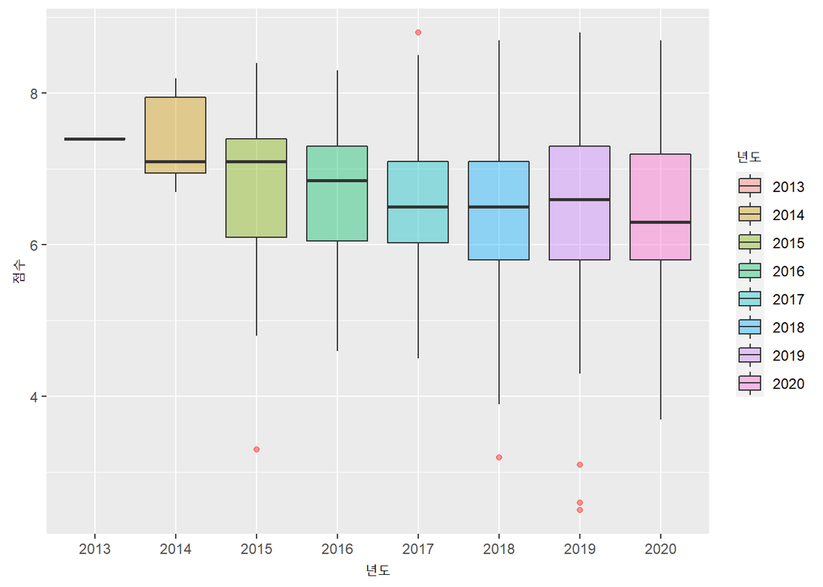

```r
library(ggplot2)
ggplot(netflix_original,aes(x=as.factor(Year),y=All_rating))+
  geom_boxplot(aes(fill=as.factor(Year)),outlier.colour = 'red',alpha=I(0.4))+
  xlab("년도") + ylab("점수") + labs(fill = "년도")
```

### Age

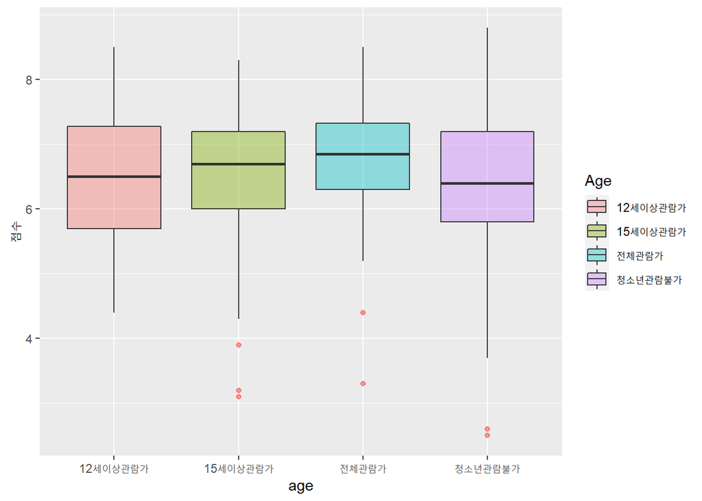

```r
ggplot(netflix_original,aes(x=as.factor(Age),y=All_rating))+
  geom_boxplot(aes(fill=as.factor(Age)),outlier.colour = 'red',alpha=I(0.4))+
  xlab("age") + ylab("점수") + labs(fill = "Age")
```

### Harmful_themes

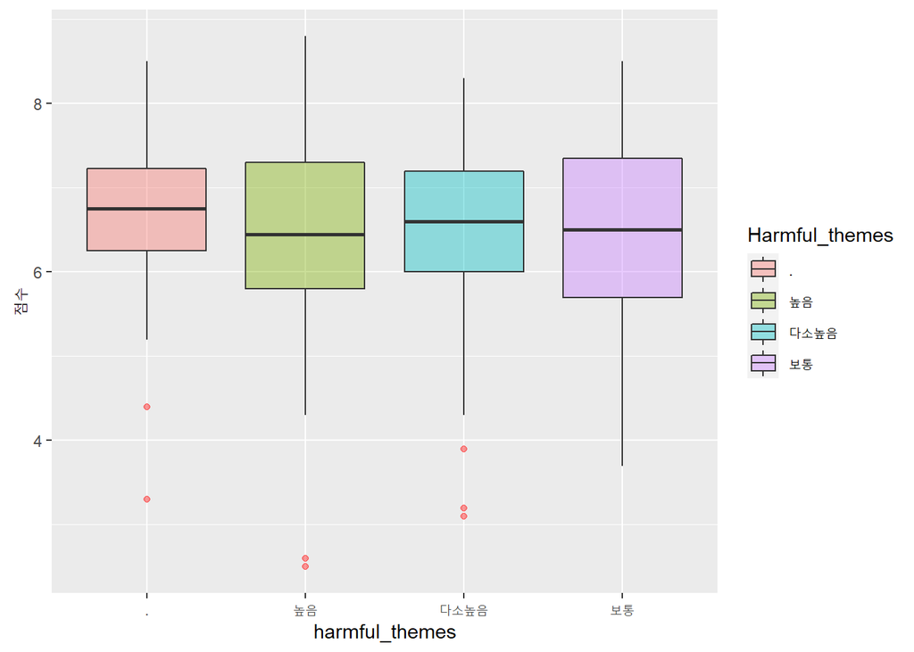

```r
ggplot(netflix_original,aes(x=as.factor(Harmful_themes),y=All_rating))+
  geom_boxplot(aes(fill=as.factor(Harmful_themes)),outlier.colour = 'red',alpha=I(0.4))+
  xlab("harmful_themes") + ylab("점수") + labs(fill = "Harmful_themes")
```

### Lewdness

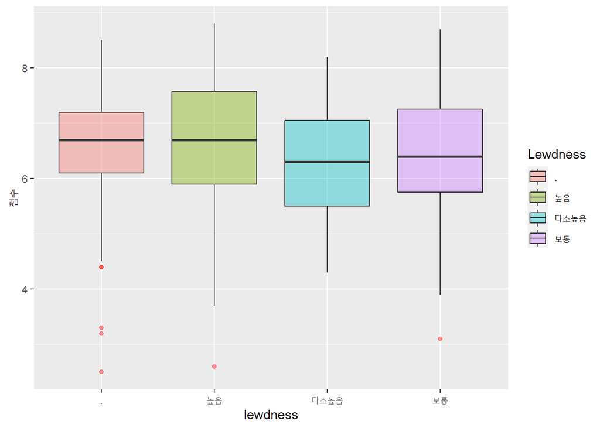

```r
ggplot(netflix_original,aes(x=as.factor(Lewdness),y=All_rating))+
  geom_boxplot(aes(fill=as.factor(Lewdness)),outlier.colour = 'red',alpha=I(0.4))+
  xlab("lewdness") + ylab("점수") + labs(fill = "Lewdness")
```

### Violence

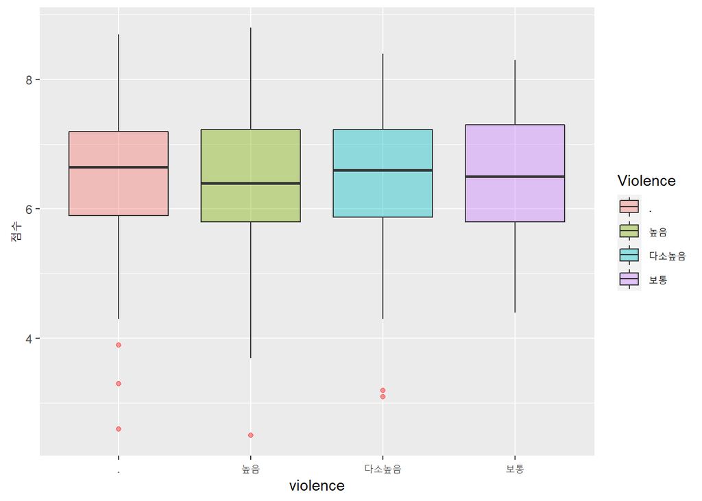

```r
ggplot(netflix_original,aes(x=as.factor(Violence),y=All_rating))+
  geom_boxplot(aes(fill=as.factor(Violence)),outlier.colour = 'red',alpha=I(0.4))+
  xlab("violence") + ylab("점수") + labs(fill = "Violence")
```

### Profanity

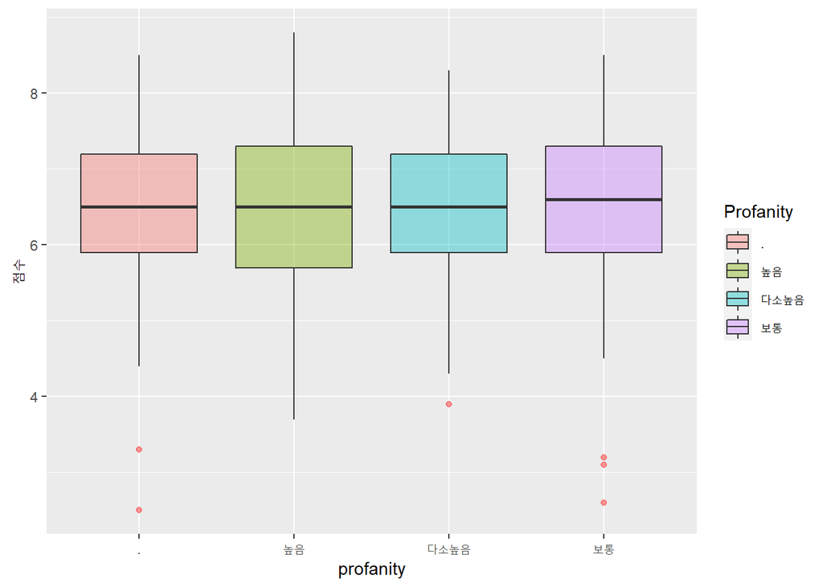

```r
ggplot(netflix_original,aes(x=as.factor(Profanity),y=All_rating))+
  geom_boxplot(aes(fill=as.factor(Profanity)),outlier.colour = 'red',alpha=I(0.4))+
  xlab("profanity") + ylab("점수") + labs(fill = "Profanity")
```

### Fear

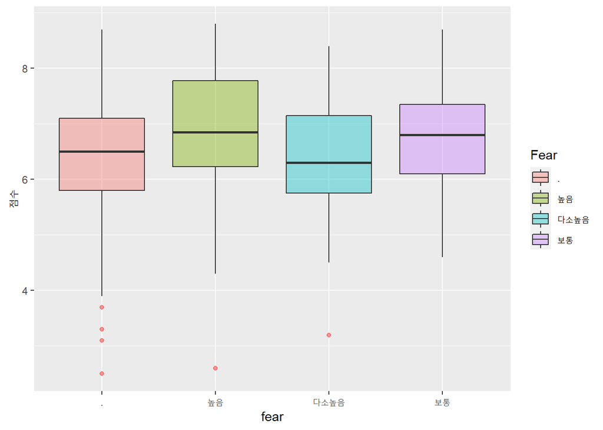

```r
ggplot(netflix_original,aes(x=as.factor(Fear),y=All_rating))+
  geom_boxplot(aes(fill=as.factor(Fear)),outlier.colour = 'red',alpha=I(0.4))+
  xlab("fear") + ylab("점수") + labs(fill = "Fear")
```

### Drugs

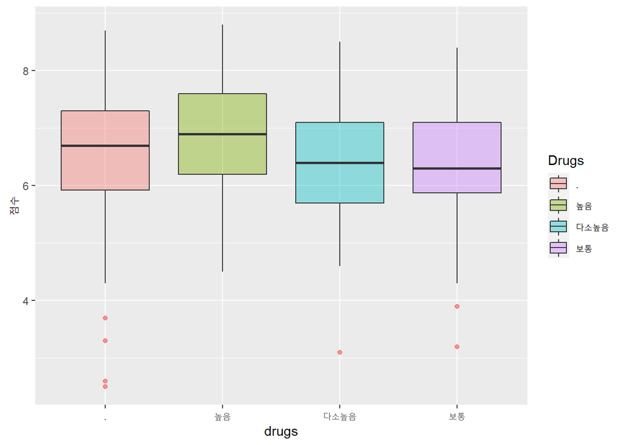

```r
ggplot(netflix_original,aes(x=as.factor(Drugs),y=All_rating))+
  geom_boxplot(aes(fill=as.factor(Drugs)),outlier.colour = 'red',alpha=I(0.4))+
  xlab("drugs") + ylab("점수") + labs(fill = "Drugs")
```

### Immatatable

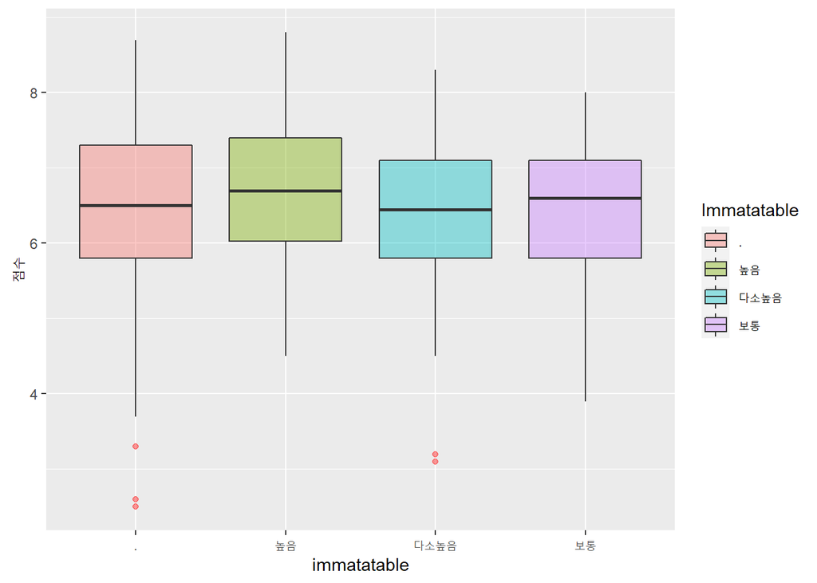

```r
ggplot(netflix_original,aes(x=as.factor(Immatatable),y=All_rating))+
  geom_boxplot(aes(fill=as.factor(Immatatable)),outlier.colour = 'red',alpha=I(0.4))+
  xlab("immatatable") + ylab("점수") + labs(fill = "Immatatable")
```

## 다중공선성확인(GVIF^(1/(2*Df)) > 2시 문제)

### 종합데이터

```r
library(car)
fit_tmp <- lm(All_rating ~ . , data=netflix_original)
vif(fit_tmp)
```

```
                             GVIF Df GVIF^(1/(2*Df))
Mean_Length              1.383836  1        1.176365
Director_max_award       1.220835  1        1.104914
twenties_rating         39.299077  1        6.268898
thirties_rating         87.511248  1        9.354745
overfourtyfive_rating   17.420181  1        4.173749
Males_rating            80.864281  1        8.992457
Famales_rating          16.522711  1        4.064814
twenties_voter         228.573895  1       15.118660
thirties_voter         640.604388  1       25.310164
overfourtyfive_voter    48.201060  1        6.942698
Males_voter           1127.698467  1       33.581222
Famales_voter           91.019415  1        9.540410
Age                    193.890514  3        2.405799
Year                     2.111556  7        1.054838
Harmful_themes         123.722352  3        2.232242
Lewdness                 3.556616  3        1.235491
Violence                 4.633821  3        1.291189
Profanity                9.116022  3        1.445332
Fear                     3.569405  3        1.236230
Drugs                    4.328034  3        1.276581
Immatatable              5.258585  3        1.318696
```

### 드라마데이터(겹친 변수가 존재 aliased)

```r
# fit_tmp <- lm(All_rating ~ . , data=netflix_drama)
# vif(fit_tmp)
```

### 영화데이터

```r
fit_tmp <- lm(All_rating ~ . , data=netflix_movie)
vif(fit_tmp)
```

```
                             GVIF Df GVIF^(1/(2*Df))
Mean_Length              1.481867  1        1.217320
Director_max_award       1.336429  1        1.156040
twenties_rating         46.008161  1        6.782932
thirties_rating         87.012018  1        9.328023
overfourtyfive_rating   18.648224  1        4.318359
Males_rating            76.521229  1        8.747641
Famales_rating          18.041253  1        4.247500
twenties_voter         177.771691  1       13.333105
thirties_voter         851.872780  1       29.186860
overfourtyfive_voter    56.367468  1        7.507827
Males_voter           1341.076137  1       36.620706
Famales_voter           84.406615  1        9.187307
Age                    180.317652  3        2.376875
Year                     2.817344  7        1.076791
Harmful_themes         112.064702  3        2.195726
Lewdness                 3.052636  3        1.204423
Violence                 4.729487  3        1.295594
Profanity                6.814645  3        1.376915
Fear                     3.545633  3        1.234854
Drugs                    3.311263  3        1.220859
Immatatable              4.464226  3        1.283190
```

## Cooks distance outlier제거

종합데이터, 드라마데이터, 영화데이터를 가지고 outlier(이상치)를 제거하는 기준으로 cooks distance를 사용하였다.

### 종합 데이터

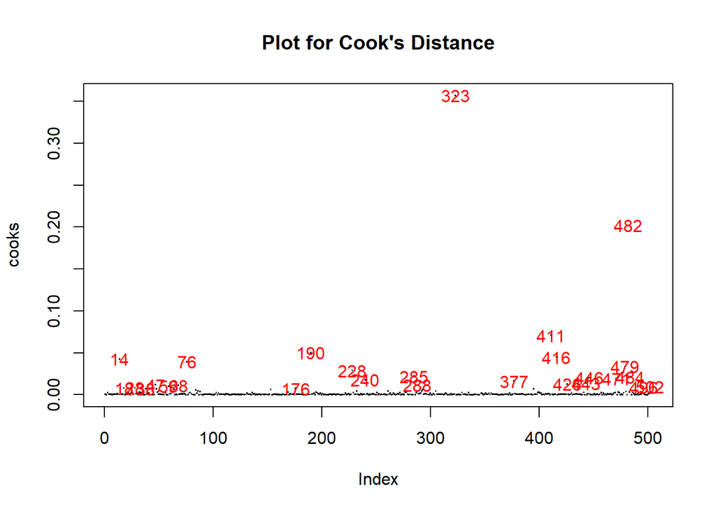

```r
fit_tmp <- lm(All_rating ~ . , data=netflix_original) #lm :  linear regression의 핵심으로, 회귀분석, 단일 계층 분석, 공분산 분석에 이용할 수 있다.
cooks <- cooks.distance(fit_tmp) # 일반회귀를 통해 cooks 값을 구한다.
plot(cooks, pch=".", cex=1.5, main = "Plot for Cook's Distance") # cooks 시각화
# plot() 함수는 x, y 인자 2개를 기본적으로 받습니다.
# cex : 기호의 크기를 지정할 때 사용 cex에 입력하는 숫자는 디폴트인 cex=1 대비 상대적인 크기를 나타냄.

text(x=1:length(cooks), y=cooks, labels = ifelse(cooks > 4/nrow(netflix), names(cooks), ""), col = "red") # 어떤 데이터인지 plot에 표시
```

```r
outlier <- names(cooks)[(cooks > 4/nrow(netflix_original))] # outlier기준: 4/(sample size)를 넘는 cooks값을 가진 데이터
outlier <- as.integer(na.omit(outlier))
netflix_original <- netflix_original[-outlier, ] # oulier로 판정된 데이터 제거
```

### 드라마 데이터

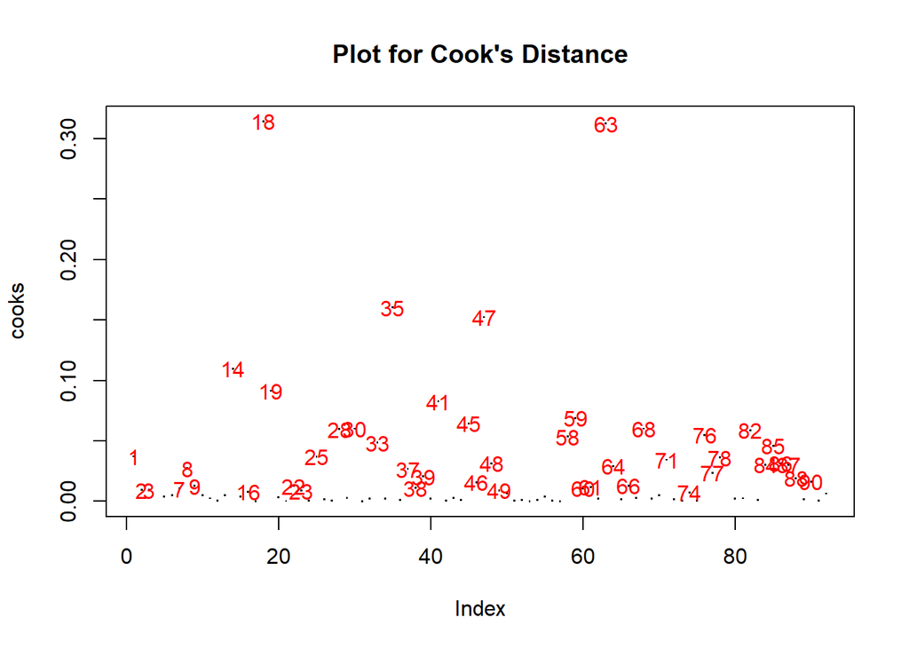

```r
fit_tmp <- lm(All_rating ~ . , data=netflix_drama)
cooks <- cooks.distance(fit_tmp)
plot(cooks, pch=".", cex=1.5, main = "Plot for Cook's Distance")

text(x=1:length(cooks), y=cooks, labels = ifelse(cooks > 4/nrow(netflix), names(cooks), ""), col = "red")
```

```r
outlier <- names(cooks)[(cooks > 4/nrow(netflix_drama))]
outlier <- as.integer(na.omit(outlier))
netflix_drama <- netflix_drama[-outlier, ]
```

### 영화 데이터

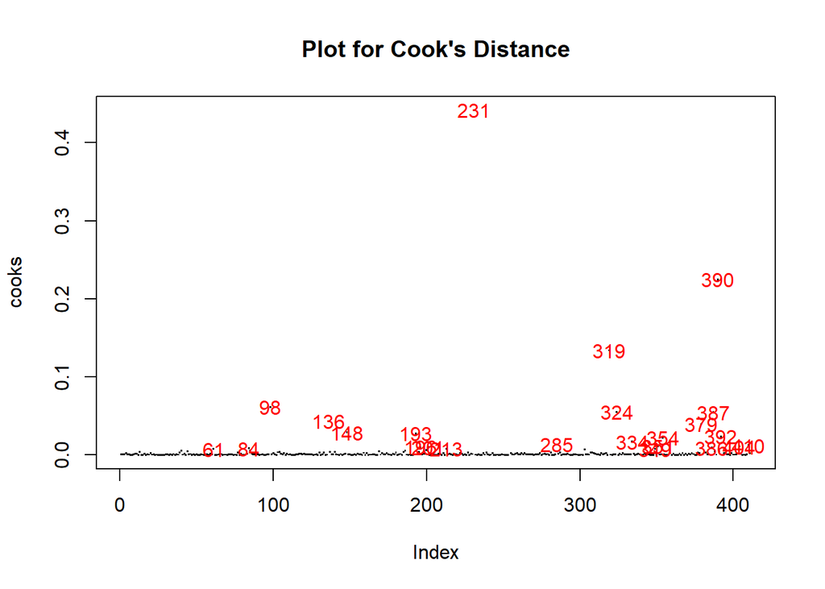

```r
fit_tmp <- lm(All_rating ~ . , data=netflix_movie)
cooks <- cooks.distance(fit_tmp)
plot(cooks, pch=".", cex=1.5, main = "Plot for Cook's Distance")

text(x=1:length(cooks), y=cooks, labels = ifelse(cooks > 4/nrow(netflix), names(cooks), ""), col = "red")
```

```r
outlier <- names(cooks)[(cooks > 4/nrow(netflix_movie))]
outlier <- as.integer(na.omit(outlier))
netflix_movie <- netflix_movie[-outlier, ]
```

## 일반회귀

### 종합 데이터

#### 세부 factor에서 유의한 값

Estimate , Std. Error, t value, Pr(>|t|) 를 확인하고, 유의미한 정도를 *의 개수를 통해 확인할 수 있다.

```r
fit_OLS_original <- lm(All_rating ~ . , data=netflix_original)
summary(fit_OLS_original) # Summary() 함수는 중심화 경향과 퍼짐정도에 대해서 quick 하게 볼 수 있는 통계량들을 제공합니다.
```

```
Call:
lm(formula = All_rating ~ ., data = netflix_original)

Residuals:
      Min        1Q    Median        3Q       Max
-0.161768 -0.033613  0.001113  0.031025  0.172785

Coefficients:
                         Estimate Std. Error t value Pr(>|t|)
(Intercept)            -2.162e-02  6.475e-02  -0.334 0.738559
Mean_Length            -1.119e-04  8.874e-05  -1.261 0.207949
Director_max_award      1.759e-05  1.309e-04   0.134 0.893157
twenties_rating         2.397e-01  1.645e-02  14.572  < 2e-16 ***
thirties_rating         3.972e-01  2.709e-02  14.664  < 2e-16 ***
overfourtyfive_rating   1.067e-01  1.143e-02   9.337  < 2e-16 ***
Males_rating            2.262e-01  2.715e-02   8.333 1.04e-15 ***
Famales_rating          3.896e-02  1.067e-02   3.652 0.000292 ***
twenties_voter         -1.611e-06  3.369e-06  -0.478 0.632707
thirties_voter         -3.210e-06  3.782e-06  -0.849 0.396510
overfourtyfive_voter   -7.295e-07  3.835e-06  -0.190 0.849229
Males_voter             1.732e-06  2.906e-06   0.596 0.551585
Famales_voter           3.279e-06  3.059e-06   1.072 0.284321
Age15세이상관람가       1.781e-03  1.785e-02   0.100 0.920559
Age전체관람가           2.645e-02  2.441e-02   1.083 0.279272
Age청소년관람불가      -8.181e-03  2.162e-02  -0.378 0.705291
Year2014               -7.409e-02  6.007e-02  -1.233 0.218119
Year2015               -2.800e-02  5.906e-02  -0.474 0.635700
Year2016               -2.123e-02  5.774e-02  -0.368 0.713299
Year2017               -1.504e-02  5.694e-02  -0.264 0.791802
Year2018               -1.207e-02  5.665e-02  -0.213 0.831373
Year2019               -1.736e-02  5.655e-02  -0.307 0.758944
Year2020                2.223e-03  5.677e-02   0.039 0.968776
Harmful_themes높음      8.237e-03  2.913e-02   0.283 0.777503
Harmful_themes다소높음  2.513e-03  2.732e-02   0.092 0.926735
Harmful_themes보통      1.984e-02  2.272e-02   0.873 0.382918
Lewdness높음           -6.407e-03  9.831e-03  -0.652 0.514948
Lewdness다소높음        7.840e-03  8.143e-03   0.963 0.336188
Lewdness보통            4.148e-03  8.265e-03   0.502 0.616023
Violence높음            5.324e-03  1.166e-02   0.457 0.648155
Violence다소높음        4.247e-03  8.436e-03   0.503 0.614946
Violence보통            1.385e-02  7.904e-03   1.752 0.080467 .
Profanity높음           9.609e-04  1.406e-02   0.068 0.945558
Profanity다소높음       3.709e-03  1.170e-02   0.317 0.751282
Profanity보통           6.046e-03  1.051e-02   0.575 0.565273
Fear높음               -9.851e-03  1.183e-02  -0.833 0.405314
Fear다소높음           -1.024e-02  9.175e-03  -1.116 0.265210
Fear보통               -1.821e-02  8.083e-03  -2.252 0.024801 *
Drugs높음               1.284e-02  1.138e-02   1.128 0.259852
Drugs다소높음           3.422e-03  8.955e-03   0.382 0.702586
Drugs보통               2.229e-03  8.185e-03   0.272 0.785535
Immatatable높음         3.466e-03  1.090e-02   0.318 0.750638
Immatatable다소높음     5.620e-03  8.431e-03   0.667 0.505419
Immatatable보통         4.656e-03  9.316e-03   0.500 0.617465
---
Signif. codes:  0 '***' 0.001 '**' 0.01 '*' 0.05 '.' 0.1 ' ' 1

Residual standard error: 0.05488 on 435 degrees of freedom
Multiple R-squared:  0.9974,    Adjusted R-squared:  0.9971
F-statistic:  3832 on 43 and 435 DF,  p-value: < 2.2e-16
```

#### 유의한 factor

ANOVA는 하나 이상의 범주 형 독립 변수 수준에 따라 양적 종속 변수 가 어떻게 변하는 지 추정하기위한 통계 검정 입니다.

ANOVA 는 독립 변수의 각 수준에서 그룹 평균 에 차이가 있는지 여부를 테스트합니다. 변량 분석. 3개이상 다수 집단을 비교할 때 사용하는 가설검정 방법으로, 다수간의 평균 비교에서 ANOVA를 통해 유의한 차이를 검정

```r
anova(fit_OLS_original) # 유의한 factor를 확인하기 위해 ANOVA함수를 이용함
```

```
Analysis of Variance Table

Response: All_rating
                       Df Sum Sq Mean Sq    F value    Pr(>F)
Mean_Length             1  16.86   16.86 5.5995e+03 < 2.2e-16 ***
Director_max_award      1  21.08   21.08 7.0007e+03 < 2.2e-16 ***
twenties_rating         1 447.36  447.36 1.4854e+05 < 2.2e-16 ***
thirties_rating         1   9.86    9.86 3.2755e+03 < 2.2e-16 ***
overfourtyfive_rating   1   0.75    0.75 2.4743e+02 < 2.2e-16 ***
Males_rating            1   0.15    0.15 4.9595e+01 7.423e-12 ***
Famales_rating          1   0.06    0.06 1.8712e+01 1.887e-05 ***
twenties_voter          1   0.01    0.01 2.4401e+00   0.11900
thirties_voter          1   0.01    0.01 3.6846e+00   0.05557 .
overfourtyfive_voter    1   0.00    0.00 1.0550e-01   0.74552
Males_voter             1   0.01    0.01 3.4057e+00   0.06565 .
Famales_voter           1   0.01    0.01 2.5241e+00   0.11284
Age                     3   0.01    0.00 1.6599e+00   0.17497
Year                    7   0.05    0.01 2.5643e+00   0.01345 *
Harmful_themes          3   0.01    0.00 7.5680e-01   0.51888
Lewdness                3   0.01    0.00 1.1232e+00   0.33931
Violence                3   0.01    0.00 9.9510e-01   0.39496
Profanity               3   0.00    0.00 3.2090e-01   0.81028
Fear                    3   0.01    0.00 1.5918e+00   0.19065
Drugs                   3   0.01    0.00 7.1510e-01   0.54336
Immatatable             3   0.00    0.00 1.7090e-01   0.91600
Residuals             435   1.31    0.00
---
Signif. codes:  0 '***' 0.001 '**' 0.01 '*' 0.05 '.' 0.1 ' ' 1
```

#### 모델 유의성 확인

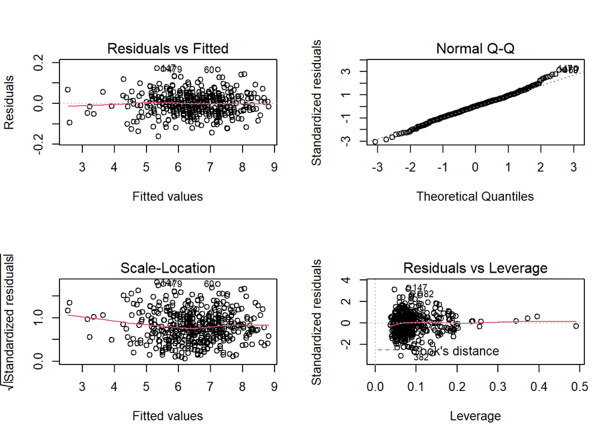

```r
par(mfrow = c(2,2)) # 한 화면에 여러 개의 그래프를 그려 비교하기 위해 par함수 사용
plot(fit_OLS_original) # fit_OLS_original의 그래프를 그려줌
```

### 드라마 데이터

#### 세부 factor에서 유의한 값

```r
fit_OLS_drama <- lm(All_rating ~ . , data=netflix_drama)
summary(fit_OLS_drama)
```

```
Call:
lm(formula = All_rating ~ ., data = netflix_drama)

Residuals:
      Min        1Q    Median        3Q       Max
-0.088039 -0.016021  0.002042  0.019048  0.077869

Coefficients: (3 not defined because of singularities)
                         Estimate Std. Error t value Pr(>|t|)
(Intercept)            -3.168e-01  1.410e-01  -2.246  0.03091 *
Mean_Length            -1.340e-03  5.919e-04  -2.263  0.02974 *
Director_max_award     -1.115e-03  6.501e-04  -1.715  0.09494 .
twenties_rating         1.280e-01  4.211e-02   3.039  0.00440 **
thirties_rating         6.118e-01  7.122e-02   8.590 3.05e-10 ***
overfourtyfive_rating   4.425e-02  3.098e-02   1.428  0.16186
Males_rating            1.295e-01  6.317e-02   2.051  0.04762 *
Famales_rating          1.192e-01  4.103e-02   2.904  0.00626 **
twenties_voter         -8.329e-06  8.898e-06  -0.936  0.35548
thirties_voter         -1.127e-05  7.851e-06  -1.435  0.15994
overfourtyfive_voter   -5.082e-06  1.096e-05  -0.464  0.64554
Males_voter             8.188e-06  7.218e-06   1.134  0.26416
Famales_voter           9.741e-06  7.679e-06   1.268  0.21277
Age15세이상관람가       1.387e-01  9.036e-02   1.535  0.13346
Age전체관람가           1.099e-01  1.144e-01   0.961  0.34287
Age청소년관람불가       1.640e-01  1.403e-01   1.168  0.25029
Year2016               -4.779e-02  6.877e-02  -0.695  0.49157
Year2017                3.784e-02  5.047e-02   0.750  0.45828
Year2018                2.503e-03  4.370e-02   0.057  0.95464
Year2019               -2.574e-02  4.451e-02  -0.578  0.56670
Year2020                1.033e-02  4.972e-02   0.208  0.83659
Harmful_themes높음             NA         NA      NA       NA
Harmful_themes다소높음  7.281e-02  1.325e-01   0.550  0.58602
Harmful_themes보통      2.019e-01  1.112e-01   1.815  0.07781 .
Lewdness높음           -7.988e-03  5.805e-02  -0.138  0.89132
Lewdness다소높음        8.690e-03  5.390e-02   0.161  0.87282
Lewdness보통           -1.859e-02  5.459e-02  -0.341  0.73543
Violence높음           -5.346e-02  3.403e-02  -1.571  0.12499
Violence다소높음       -9.017e-03  2.924e-02  -0.308  0.75958
Violence보통           -6.615e-02  2.950e-02  -2.242  0.03122 *
Profanity높음                  NA         NA      NA       NA
Profanity다소높음              NA         NA      NA       NA
Profanity보통           6.229e-02  8.830e-02   0.705  0.48509
Fear높음                6.090e-02  3.209e-02   1.898  0.06575 .
Fear다소높음            1.623e-02  3.051e-02   0.532  0.59796
Fear보통                3.256e-02  2.837e-02   1.148  0.25872
Drugs높음               1.941e-02  4.718e-02   0.411  0.68318
Drugs다소높음          -2.833e-02  4.495e-02  -0.630  0.53257
Drugs보통               4.778e-02  3.954e-02   1.209  0.23471
Immatatable높음        -4.075e-03  4.107e-02  -0.099  0.92152
Immatatable다소높음    -2.852e-02  3.772e-02  -0.756  0.45451
Immatatable보통        -4.945e-03  5.331e-02  -0.093  0.92660
---
Signif. codes:  0 '***' 0.001 '**' 0.01 '*' 0.05 '.' 0.1 ' ' 1

Residual standard error: 0.0514 on 36 degrees of freedom
Multiple R-squared:  0.9988,    Adjusted R-squared:  0.9975
F-statistic:   788 on 38 and 36 DF,  p-value: < 2.2e-16
```

#### 유의한 factor

```r
anova(fit_OLS_drama)
```

```
Analysis of Variance Table

Response: All_rating
                      Df Sum Sq Mean Sq    F value    Pr(>F)
Mean_Length            1  8.170   8.170  3092.5916 < 2.2e-16 ***
Director_max_award     1  0.568   0.568   215.0724 < 2.2e-16 ***
twenties_rating        1 67.718  67.718 25634.0027 < 2.2e-16 ***
thirties_rating        1  2.363   2.363   894.6601 < 2.2e-16 ***
overfourtyfive_rating  1  0.075   0.075    28.2880 5.657e-06 ***
Males_rating           1  0.004   0.004     1.4126   0.24240
Famales_rating         1  0.088   0.088    33.4146 1.365e-06 ***
twenties_voter         1  0.009   0.009     3.2898   0.07806 .
thirties_voter         1  0.002   0.002     0.7715   0.38557
overfourtyfive_voter   1  0.000   0.000     0.1310   0.71949
Males_voter            1  0.001   0.001     0.2577   0.61482
Famales_voter          1  0.001   0.001     0.3001   0.58722
Age                    3  0.018   0.006     2.3223   0.09145 .
Year                   5  0.026   0.005     1.9953   0.10286
Harmful_themes         2  0.016   0.008     2.9861   0.06312 .
Lewdness               3  0.002   0.001     0.2680   0.84803
Violence               3  0.010   0.003     1.3163   0.28413
Profanity              1  0.001   0.001     0.2043   0.65400
Fear                   3  0.008   0.003     1.0103   0.39942
Drugs                  3  0.020   0.007     2.5823   0.06843 .
Immatatable            3  0.002   0.001     0.3005   0.82479
Residuals             36  0.095   0.003
---
Signif. codes:  0 '***' 0.001 '**' 0.01 '*' 0.05 '.' 0.1 ' ' 1
```

#### 모델 유의성 확인

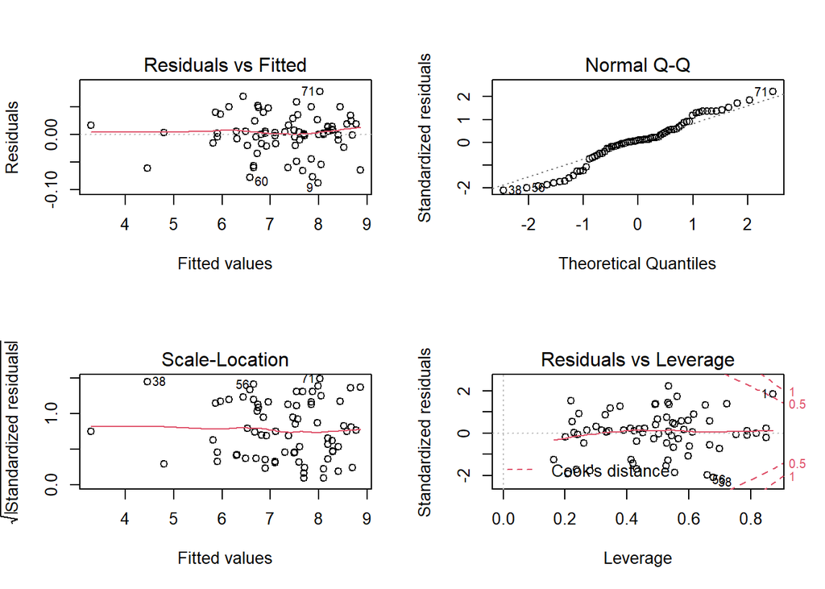

```r
par(mfrow = c(2,2))
plot(fit_OLS_drama)
```

### 영화 데이터

#### 세부 factor에서 유의한 값

```r
fit_OLS_movie <- lm(All_rating ~ . , data=netflix_movie)
summary(fit_OLS_movie)
```

```
Call:
lm(formula = All_rating ~ ., data = netflix_movie)

Residuals:
      Min        1Q    Median        3Q       Max
-0.157684 -0.032878  0.000446  0.030084  0.176926

Coefficients:
                         Estimate Std. Error t value Pr(>|t|)
(Intercept)             2.935e-03  6.307e-02   0.047   0.9629
Mean_Length            -5.580e-05  1.113e-04  -0.501   0.6163
Director_max_award      1.648e-05  1.346e-04   0.123   0.9026
twenties_rating         2.654e-01  1.855e-02  14.312  < 2e-16 ***
thirties_rating         3.288e-01  3.205e-02  10.259  < 2e-16 ***
overfourtyfive_rating   1.301e-01  1.330e-02   9.776  < 2e-16 ***
Males_rating            2.535e-01  3.221e-02   7.869 4.55e-14 ***
Famales_rating          3.023e-02  1.194e-02   2.532   0.0118 *
twenties_voter         -3.865e-06  4.912e-06  -0.787   0.4319
thirties_voter         -7.092e-06  6.278e-06  -1.130   0.2594
overfourtyfive_voter    1.316e-06  5.583e-06   0.236   0.8138
Males_voter             3.844e-06  4.680e-06   0.822   0.4119
Famales_voter           6.511e-06  4.824e-06   1.350   0.1780
Age15세이상관람가      -1.239e-02  1.822e-02  -0.680   0.4969
Age전체관람가           2.456e-02  2.525e-02   0.973   0.3314
Age청소년관람불가      -1.718e-02  2.227e-02  -0.771   0.4409
Year2014               -9.091e-02  5.724e-02  -1.588   0.1132
Year2015               -4.302e-02  5.698e-02  -0.755   0.4508
Year2016               -4.587e-02  5.535e-02  -0.829   0.4079
Year2017               -4.039e-02  5.437e-02  -0.743   0.4580
Year2018               -3.466e-02  5.414e-02  -0.640   0.5224
Year2019               -3.762e-02  5.404e-02  -0.696   0.4869
Year2020               -2.146e-02  5.419e-02  -0.396   0.6924
Harmful_themes높음      1.296e-02  3.003e-02   0.432   0.6664
Harmful_themes다소높음  7.417e-03  2.837e-02   0.261   0.7939
Harmful_themes보통      8.909e-03  2.357e-02   0.378   0.7057
Lewdness높음           -6.794e-03  1.072e-02  -0.634   0.5266
Lewdness다소높음        7.047e-03  8.363e-03   0.843   0.4000
Lewdness보통            2.837e-03  8.380e-03   0.339   0.7351
Violence높음            6.536e-03  1.250e-02   0.523   0.6015
Violence다소높음        7.262e-03  8.784e-03   0.827   0.4090
Violence보통            1.501e-02  8.116e-03   1.850   0.0652 .
Profanity높음           9.295e-03  1.401e-02   0.663   0.5076
Profanity다소높음       6.933e-03  1.139e-02   0.609   0.5432
Profanity보통           8.934e-03  1.039e-02   0.860   0.3903
Fear높음               -1.794e-02  1.288e-02  -1.393   0.1646
Fear다소높음           -7.069e-03  9.973e-03  -0.709   0.4789
Fear보통               -1.538e-02  8.650e-03  -1.777   0.0764 .
Drugs높음               3.632e-03  1.224e-02   0.297   0.7668
Drugs다소높음           4.060e-04  8.924e-03   0.045   0.9637
Drugs보통              -1.610e-03  8.160e-03  -0.197   0.8437
Immatatable높음         7.314e-03  1.139e-02   0.642   0.5213
Immatatable다소높음     6.865e-03  8.676e-03   0.791   0.4293
Immatatable보통         9.528e-03  9.629e-03   0.989   0.3231
---
Signif. codes:  0 '***' 0.001 '**' 0.01 '*' 0.05 '.' 0.1 ' ' 1

Residual standard error: 0.05207 on 349 degrees of freedom
Multiple R-squared:  0.9974,    Adjusted R-squared:  0.997
F-statistic:  3068 on 43 and 349 DF,  p-value: < 2.2e-16
```

### 유의한 factor

```r
anova(fit_OLS_movie)
```

```
Analysis of Variance Table

Response: All_rating
                       Df Sum Sq Mean Sq    F value    Pr(>F)
Mean_Length             1   0.29    0.29 1.0525e+02 < 2.2e-16 ***
Director_max_award      1  22.51   22.51 8.3051e+03 < 2.2e-16 ***
twenties_rating         1 326.94  326.94 1.2061e+05 < 2.2e-16 ***
thirties_rating         1   6.94    6.94 2.5613e+03 < 2.2e-16 ***
overfourtyfive_rating   1   0.63    0.63 2.3189e+02 < 2.2e-16 ***
Males_rating            1   0.15    0.15 5.6467e+01 4.849e-13 ***
Famales_rating          1   0.02    0.02 8.1993e+00  0.004444 **
twenties_voter          1   0.00    0.00 1.1732e+00  0.279500
thirties_voter          1   0.01    0.01 4.1756e+00  0.041760 *
overfourtyfive_voter    1   0.00    0.00 1.4131e+00  0.235349
Males_voter             1   0.01    0.01 2.4457e+00  0.118757
Famales_voter           1   0.01    0.01 3.6898e+00  0.055560 .
Age                     3   0.01    0.00 1.2340e+00  0.297230
Year                    7   0.04    0.01 1.9516e+00  0.060911 .
Harmful_themes          3   0.00    0.00 1.8770e-01  0.904741
Lewdness                3   0.01    0.00 6.9730e-01  0.554192
Violence                3   0.01    0.00 1.3560e+00  0.256088
Profanity               3   0.00    0.00 4.9650e-01  0.684926
Fear                    3   0.01    0.00 1.4044e+00  0.241259
Drugs                   3   0.00    0.00 1.7390e-01  0.914007
Immatatable             3   0.00    0.00 4.0130e-01  0.752128
Residuals             349   0.95    0.00
---
Signif. codes:  0 '***' 0.001 '**' 0.01 '*' 0.05 '.' 0.1 ' ' 1
```

#### 모델 유의성 확인

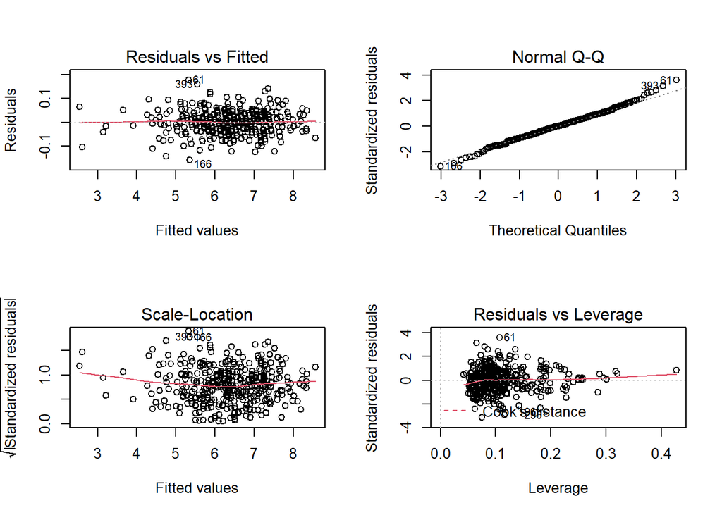

```r
par(mfrow = c(2,2))
plot(fit_OLS_movie)
```

## 로버스트 회귀

### 종합 데이터

#### 유의한 factor (t값 1.96으로 평가)

```r
# 로버스트 회귀
library('MASS') # 로버스트 회귀를 위해 MASS 라이브러리 로드
fit_m_original <- rlm(All_rating ~ . , data = netflix_original)
summary(fit_m_original) # MASS패키지의 함수인 rlm을 사용하여 로버스트 회귀분석 함.
```

```
Call: rlm(formula = All_rating ~ ., data = netflix_original)
Residuals:
      Min        1Q    Median        3Q       Max
-0.168271 -0.032207  0.001292  0.031375  0.170965

Coefficients:
                       Value   Std. Error t value
(Intercept)            -0.0039  0.0611    -0.0634
Mean_Length            -0.0001  0.0001    -1.4161
Director_max_award      0.0000  0.0001     0.2875
twenties_rating         0.2565  0.0155    16.5112
thirties_rating         0.4027  0.0256    15.7447
overfourtyfive_rating   0.1136  0.0108    10.5238
Males_rating            0.2003  0.0256     7.8159
Famales_rating          0.0341  0.0101     3.3876
twenties_voter          0.0000  0.0000    -0.1695
thirties_voter          0.0000  0.0000    -0.7404
overfourtyfive_voter    0.0000  0.0000     0.0015
Males_voter             0.0000  0.0000     0.3991
Famales_voter           0.0000  0.0000     0.8654
Age15세이상관람가       0.0025  0.0169     0.1460
Age전체관람가           0.0225  0.0230     0.9781
Age청소년관람불가      -0.0030  0.0204    -0.1477
Year2014               -0.0755  0.0567    -1.3312
Year2015               -0.0335  0.0558    -0.6006
Year2016               -0.0249  0.0545    -0.4570
Year2017               -0.0182  0.0538    -0.3393
Year2018               -0.0173  0.0535    -0.3226
Year2019               -0.0207  0.0534    -0.3877
Year2020               -0.0025  0.0536    -0.0465
Harmful_themes높음      0.0059  0.0275     0.2159
Harmful_themes다소높음  0.0012  0.0258     0.0475
Harmful_themes보통      0.0175  0.0215     0.8135
Lewdness높음           -0.0074  0.0093    -0.7971
Lewdness다소높음        0.0048  0.0077     0.6198
Lewdness보통            0.0057  0.0078     0.7349
Violence높음            0.0023  0.0110     0.2114
Violence다소높음        0.0040  0.0080     0.5029
Violence보통            0.0092  0.0075     1.2395
Profanity높음           0.0045  0.0133     0.3384
Profanity다소높음       0.0053  0.0110     0.4829
Profanity보통           0.0060  0.0099     0.6006
Fear높음               -0.0069  0.0112    -0.6147
Fear다소높음           -0.0054  0.0087    -0.6224
Fear보통               -0.0159  0.0076    -2.0800
Drugs높음               0.0063  0.0107     0.5881
Drugs다소높음          -0.0020  0.0085    -0.2369
Drugs보통              -0.0025  0.0077    -0.3238
Immatatable높음        -0.0001  0.0103    -0.0119
Immatatable다소높음     0.0028  0.0080     0.3480
Immatatable보통         0.0011  0.0088     0.1237

Residual standard error: 0.04704 on 435 degrees of freedom
```

```r
anova(fit_m_original)
```

```
Analysis of Variance Table

Response: All_rating
                      Df Sum Sq Mean Sq F value Pr(>F)
Mean_Length            1  15.23   15.23
Director_max_award     1  19.33   19.33
twenties_rating        1 414.06  414.06
thirties_rating        1   7.90    7.90
overfourtyfive_rating  1   0.67    0.67
Males_rating           1   0.09    0.09
Famales_rating         1   0.04    0.04
twenties_voter         1   0.00    0.00
thirties_voter         1   0.01    0.01
overfourtyfive_voter   1   0.00    0.00
Males_voter            1   0.01    0.01
Famales_voter          1   0.00    0.00
Age                    3   0.01    0.00
Year                   7   0.05    0.01
Harmful_themes         3   0.01    0.00
Lewdness               3   0.01    0.00
Violence               3   0.00    0.00
Profanity              3   0.00    0.00
Fear                   3   0.01    0.00
Drugs                  3   0.00    0.00
Immatatable            3   0.00    0.00
Residuals                  1.32
```

#### 모델 유의성 확인

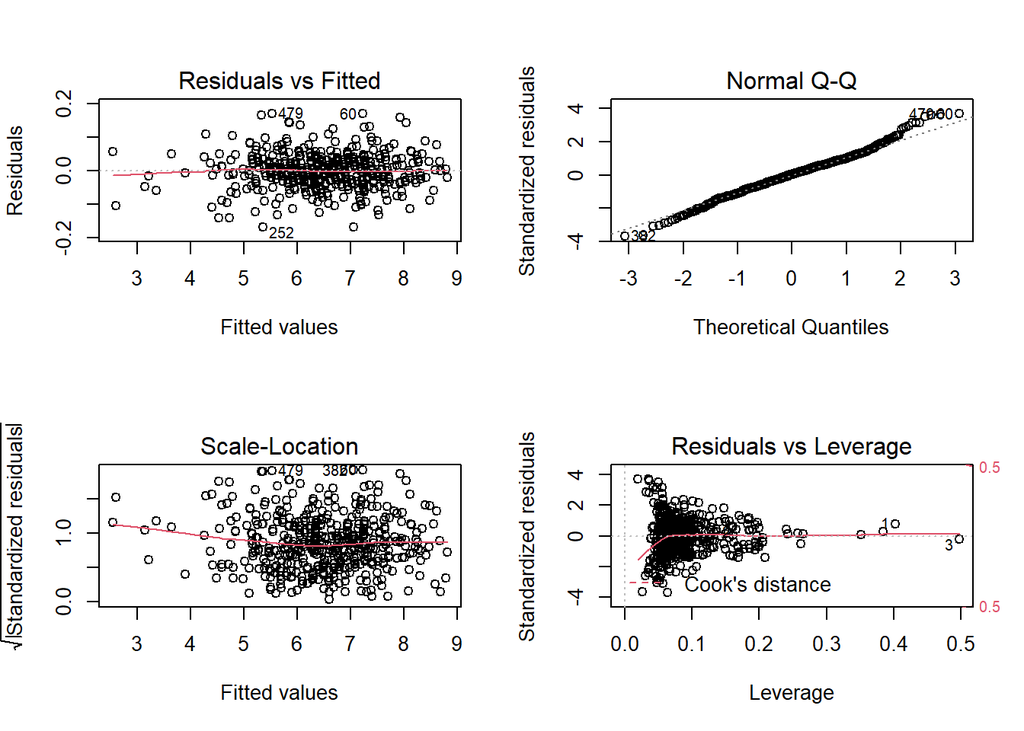

```r
par(mfrow = c(2,2))
plot(fit_m_original)
```

### 드라마 데이터(rlm이 중복쌍을 지원 안함)

```r
# fit_m_drama <- rlm(All_rating ~ . , data=netflix_drama)
# summary(fit_m_drama)
```

```r
# anova(fit_m_drama)
```

```r
# par(mfrow = c(2,2))
# plot(fit_m_drama)
```

### 영화 데이터

#### 유의한 factor (t값 1.96으로 평가)

```r
fit_m_movie <- rlm(All_rating ~ . , data=netflix_movie)
summary(fit_m_movie)
```

```
Call: rlm(formula = All_rating ~ ., data = netflix_movie)
Residuals:
       Min         1Q     Median         3Q        Max
-0.1627724 -0.0315257  0.0002826  0.0302416  0.1760757

Coefficients:
                       Value   Std. Error t value
(Intercept)             0.0214  0.0608     0.3519
Mean_Length            -0.0001  0.0001    -0.8248
Director_max_award      0.0000  0.0001     0.3441
twenties_rating         0.2721  0.0179    15.2258
thirties_rating         0.3346  0.0309    10.8342
overfourtyfive_rating   0.1309  0.0128    10.2112
Males_rating            0.2381  0.0310     7.6698
Famales_rating          0.0304  0.0115     2.6422
twenties_voter          0.0000  0.0000    -0.5381
thirties_voter          0.0000  0.0000    -1.0082
overfourtyfive_voter    0.0000  0.0000     0.3477
Males_voter             0.0000  0.0000     0.6480
Famales_voter           0.0000  0.0000     1.1891
Age15세이상관람가      -0.0094  0.0176    -0.5360
Age전체관람가           0.0216  0.0243     0.8882
Age청소년관람불가      -0.0099  0.0215    -0.4634
Year2014               -0.0905  0.0552    -1.6411
Year2015               -0.0461  0.0549    -0.8398
Year2016               -0.0475  0.0533    -0.8914
Year2017               -0.0424  0.0524    -0.8091
Year2018               -0.0385  0.0522    -0.7382
Year2019               -0.0381  0.0521    -0.7318
Year2020               -0.0230  0.0522    -0.4398
Harmful_themes높음      0.0087  0.0289     0.3000
Harmful_themes다소높음  0.0043  0.0273     0.1563
Harmful_themes보통      0.0070  0.0227     0.3075
Lewdness높음           -0.0098  0.0103    -0.9511
Lewdness다소높음        0.0065  0.0081     0.8095
Lewdness보통            0.0052  0.0081     0.6490
Violence높음            0.0037  0.0120     0.3076
Violence다소높음        0.0075  0.0085     0.8862
Violence보통            0.0101  0.0078     1.2965
Profanity높음           0.0091  0.0135     0.6707
Profanity다소높음       0.0077  0.0110     0.7003
Profanity보통           0.0074  0.0100     0.7395
Fear높음               -0.0129  0.0124    -1.0425
Fear다소높음           -0.0033  0.0096    -0.3480
Fear보통               -0.0128  0.0083    -1.5371
Drugs높음               0.0001  0.0118     0.0120
Drugs다소높음          -0.0036  0.0086    -0.4243
Drugs보통              -0.0038  0.0079    -0.4820
Immatatable높음         0.0050  0.0110     0.4556
Immatatable다소높음     0.0049  0.0084     0.5905
Immatatable보통         0.0060  0.0093     0.6494

Residual standard error: 0.04638 on 349 degrees of freedom
```

```r
anova(fit_m_movie)
```

```
Analysis of Variance Table

Response: All_rating
                      Df  Sum Sq Mean Sq F value Pr(>F)
Mean_Length            1   0.241   0.241
Director_max_award     1  21.418  21.418
twenties_rating        1 303.705 303.705
thirties_rating        1   5.899   5.899
overfourtyfive_rating  1   0.576   0.576
Males_rating           1   0.099   0.099
Famales_rating         1   0.021   0.021
twenties_voter         1   0.002   0.002
thirties_voter         1   0.011   0.011
overfourtyfive_voter   1   0.005   0.005
Males_voter            1   0.006   0.006
Famales_voter          1   0.006   0.006
Age                    3   0.008   0.003
Year                   7   0.035   0.005
Harmful_themes         3   0.001   0.000
Lewdness               3   0.007   0.002
Violence               3   0.005   0.002
Profanity              3   0.002   0.001
Fear                   3   0.007   0.002
Drugs                  3   0.001   0.000
Immatatable            3   0.001   0.000
Residuals                  0.955
```

#### 모델 유의성 확인

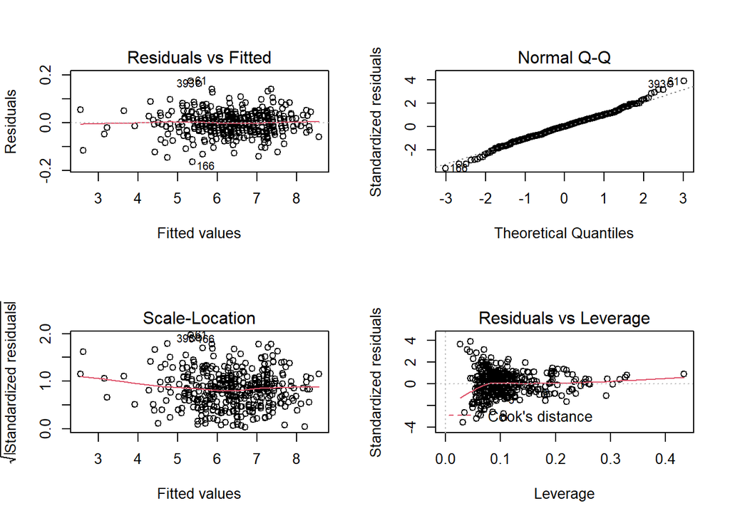

```r
par(mfrow = c(2,2))
plot(fit_m_movie)
```

**로버스트 회귀에서 유의한 factor는 일반 회귀에서도 유의함**

**개선 결과 유의한 factor가 줄어듬**

**데이터 셋을 둘로 나눴을 때 cooks에서 많은 value가 제거 됨**